# datos_liga

Enrique, Miguel, Sergio

29 de diciembre de 2022

# 1 INTRODUCCIÓN Y DEFINICIÓN DE OBJETIVOS

- ¿Qué hace que un equipo gane un partido?
- ¿Qué variables influyen en las victorias?
- Predecir el ganador de un partido

```r
# Librerías
library(dplyr)
library(tidyr)
library(knitr)
library(readr)
library(ggplot2)
library(cowplot)
```

# 2 ANÁLISIS EXPLORATORIO INICIAL

```r
laliga <- read_csv("combined_data_laliga.csv")
```

```r
# primeros estadisticos de clase
str(laliga)
```

```
## spc_tbl_ [2,660 × 41] (S3: spec_tbl_df/tbl_df/tbl/data.frame)
##  $ ...1                         : num [1:2660] 0 1 2 3 4 5 6 7 8 9 ...
##  $ Home Team                    : chr [1:2660] "MÁLAGA" "SEVILLA FC" "GRANADA" "ALMERÍA" ...
##  $ Away Team                    : chr [1:2660] "ATHLETIC" "VALENCIA" "DEPORTIVO" "ESPANYOL" ...
##  $ Score                        : chr [1:2660] "1-0" "1-1" "2-1" "1-1" ...
##  $ Half Time Score              : chr [1:2660] "1-0" "1-0" "0-1" "0-0" ...
##  $ Match Excitement             : num [1:2660] 4.4 4.7 4.6 5.6 3.7 5.1 7 4.7 4.7 2.1 ...
##  $ Home Team Rating             : num [1:2660] 6 6.5 7.2 6.9 6.5 8 7.3 5.6 6.9 6.9 ...
##  $ Away Team Rating             : num [1:2660] 5.7 6.8 5.9 5.5 5.9 5.3 5.5 7.3 5.5 5.9 ...
##  $ Home Team Possession %       : num [1:2660] 40 47 53 56 41 72 59 53 63 59 ...
##  $ Away Team Possession %       : num [1:2660] 60 53 47 44 59 28 41 47 37 41 ...
##  $ Home Team Off Target Shots   : num [1:2660] 5 4 6 7 5 5 4 4 3 5 ...
##  $ Home Team On Target Shots    : num [1:2660] 3 3 3 6 5 6 9 2 8 2 ...
##  $ Home Team Total Shots        : num [1:2660] 12 12 10 19 12 12 20 9 14 8 ...
##  $ Home Team Blocked Shots      : num [1:2660] 4 5 1 6 2 1 7 3 3 1 ...
##  $ Home Team Corners            : num [1:2660] 5 3 5 11 5 3 4 3 8 2 ...
##  $ Home Team Throw Ins          : num [1:2660] 13 20 25 26 28 23 21 16 25 23 ...
##  $ Home Team Pass Success %     : num [1:2660] 69 76 79 81 60 93 82 80 88 79 ...
##  $ Home Team Aerials Won        : num [1:2660] 11 13 20 19 29 2 27 19 23 21 ...
##  $ Home Team Clearances         : num [1:2660] 16 16 21 25 17 2 15 12 13 20 ...
##  $ Home Team Fouls              : num [1:2660] 13 23 13 8 13 11 19 11 9 13 ...
##  $ Home Team Yellow Cards       : num [1:2660] 3 4 1 3 4 0 4 1 1 2 ...
##  $ Home Team Second Yellow Cards: num [1:2660] 0 0 0 0 0 0 0 0 0 0 ...
##  $ Home Team Red Cards          : num [1:2660] 2 0 0 0 0 1 0 0 0 0 ...
##  $ Away Team Off Target Shots   : num [1:2660] 5 5 1 6 7 3 8 5 6 3 ...
##  $ Away Team On Target Shots    : num [1:2660] 5 1 1 2 4 0 3 6 2 2 ...
##  $ Away Team Total Shots        : num [1:2660] 12 11 8 12 19 3 12 12 8 9 ...
##  $ Away Team Blocked Shots      : num [1:2660] 2 5 6 4 8 0 1 1 0 4 ...
##  $ Away Team Corners            : num [1:2660] 4 3 3 7 6 1 4 4 5 4 ...
##  $ Away Team Throw Ins          : num [1:2660] 22 27 30 19 36 19 19 14 18 34 ...
##  $ Away Team Pass Success %     : num [1:2660] 84 79 76 70 75 81 74 78 79 68 ...
##  $ Away Team Aerials Won        : num [1:2660] 17 14 10 11 25 4 22 21 15 26 ...
##  $ Away Team Clearances         : num [1:2660] 14 16 14 20 20 17 7 18 27 15 ...
##  $ Away Team Fouls              : num [1:2660] 9 8 26 9 14 13 15 14 13 17 ...
##  $ Away Team Yellow Cards       : num [1:2660] 3 2 3 3 1 1 1 3 2 2 ...
##  $ Away Team Second Yellow Cards: num [1:2660] 0 0 0 1 0 0 0 0 0 0 ...
##  $ Away Team Red Cards          : num [1:2660] 0 1 0 0 0 0 0 0 0 0 ...
##  $ Home Team Goals Scored       : num [1:2660] 1 1 2 1 1 3 3 0 2 0 ...
##  $ Away Team Goals Scored       : num [1:2660] 0 1 1 1 0 0 1 2 0 0 ...
##  $ Home Team Goals Conceeded    : num [1:2660] 0 1 1 1 0 0 1 2 0 0 ...
```

[output cut: 32 more lines]

```
##   ..   `Away Team Throw Ins` = col_double(),
##   ..   `Away Team Pass Success %` = col_double(),
##   ..   `Away Team Aerials Won` = col_double(),
##   ..   `Away Team Clearances` = col_double(),
##   ..   `Away Team Fouls` = col_double(),
##   ..   `Away Team Yellow Cards` = col_double(),
##   ..   `Away Team Second Yellow Cards` = col_double(),
##   ..   `Away Team Red Cards` = col_double(),
##   ..   `Home Team Goals Scored` = col_double(),
##   ..   `Away Team Goals Scored` = col_double(),
##   ..   `Home Team Goals Conceeded` = col_double(),
##   ..   `Away Team Goals Conceeded` = col_double(),
##   ..   year = col_double()
##   .. )
##  - attr(*, "problems")=<externalptr>
```

```r
summary(laliga) #medias y medianas son bastante similares, asi que se pueden analizar como normales
```

```
##       ...1         Home Team          Away Team            Score
##  Min.   :   0.0   Length:2660        Length:2660        Length:2660
##  1st Qu.: 664.8   Class :character   Class :character   Class :character
##  Median :1329.5   Mode  :character   Mode  :character   Mode  :character
##  Mean   :1329.5
##  3rd Qu.:1994.2
##  Max.   :2659.0
##  Half Time Score    Match Excitement Home Team Rating Away Team Rating
##  Length:2660        Min.   : 1.400   Min.   : 2.800   Min.   : 3.000
##  Class :character   1st Qu.: 3.900   1st Qu.: 5.700   1st Qu.: 5.400
##  Mode  :character   Median : 5.100   Median : 6.400   Median : 6.000
##                     Mean   : 5.249   Mean   : 6.369   Mean   : 6.045
##                     3rd Qu.: 6.300   3rd Qu.: 6.900   3rd Qu.: 6.600
##                     Max.   :10.000   Max.   :10.000   Max.   :10.000
##  Home Team Possession % Away Team Possession % Home Team Off Target Shots
##  Min.   :18.00          Min.   :17.00          Min.   : 0.000
##  1st Qu.:44.00          1st Qu.:41.00          1st Qu.: 4.000
##  Median :52.00          Median :48.00          Median : 5.000
##  Mean   :51.54          Mean   :48.46          Mean   : 5.533
##  3rd Qu.:59.00          3rd Qu.:56.00          3rd Qu.: 7.000
##  Max.   :83.00          Max.   :82.00          Max.   :18.000
##  Home Team On Target Shots Home Team Total Shots Home Team Blocked Shots
##  Min.   : 0.000            Min.   : 2.00         Min.   : 0.000
##  1st Qu.: 3.000            1st Qu.:10.00         1st Qu.: 1.000
##  Median : 4.000            Median :13.00         Median : 3.000
##  Mean   : 4.648            Mean   :13.08         Mean   : 2.913
##  3rd Qu.: 6.000            3rd Qu.:16.00         3rd Qu.: 4.000
##  Max.   :17.000            Max.   :33.00         Max.   :12.000
##  Home Team Corners Home Team Throw Ins Home Team Pass Success %
##  Min.   : 0.000    Min.   : 5.0        Min.   :46.00
##  1st Qu.: 3.000    1st Qu.:18.0        1st Qu.:73.00
##  Median : 5.000    Median :22.0        Median :78.00
##  Mean   : 5.395    Mean   :22.5        Mean   :77.71
##  3rd Qu.: 7.000    3rd Qu.:27.0        3rd Qu.:84.00
##  Max.   :20.000    Max.   :49.0        Max.   :93.00
##  Home Team Aerials Won Home Team Clearances Home Team Fouls
##  Min.   : 2.0          Min.   : 1.00        Min.   : 1.00
##  1st Qu.:12.0          1st Qu.:12.00        1st Qu.:11.00
##  Median :16.0          Median :17.00        Median :14.00
##  Mean   :17.1          Mean   :17.71        Mean   :13.75
```

[output cut: 36 more lines]

```
##  Max.   :30.00   Max.   :8.000          Max.   :2.00000
##  Away Team Red Cards Home Team Goals Scored Away Team Goals Scored
##  Min.   :0.00000     Min.   : 0.000         Min.   :0.000
##  1st Qu.:0.00000     1st Qu.: 1.000         1st Qu.:0.000
##  Median :0.00000     Median : 1.000         Median :1.000
##  Mean   :0.04887     Mean   : 1.518         Mean   :1.141
##  3rd Qu.:0.00000     3rd Qu.: 2.000         3rd Qu.:2.000
##  Max.   :2.00000     Max.   :10.000         Max.   :8.000
##  Home Team Goals Conceeded Away Team Goals Conceeded      year
##  Min.   :0.000             Min.   : 0.000            Min.   :2014
##  1st Qu.:0.000             1st Qu.: 1.000            1st Qu.:2015
##  Median :1.000             Median : 1.000            Median :2017
##  Mean   :1.141             Mean   : 1.518            Mean   :2017
##  3rd Qu.:2.000             3rd Qu.: 2.000            3rd Qu.:2019
##  Max.   :8.000             Max.   :10.000            Max.   :2020
```

El dataframe contiene todos los partidos de la liga española de 7 temporadas (de 2014 a 2020).

- 2660 observaciones (partidos)
- 41 variables

**Home Team**: Equipo local  
**Away Team**: Equipo visitante  
**Score**: Resultado  
**Half Time Score**: Resultado al descanso  
**Match Excitement**: Emoción del partido (subjetiva)  
**Home Team Rating**: Nota del local  
**Away Team Rating**: Nota del visitante  
**Home Team Possession**: Posesión local  
**Away Team Possession**: Posesión visitante  
**Home Team off Target Shots**: Tiros fuera local  
**Home Team on Target Shots**: Tiros a puerta local  
**Home Team Total Shots**: Total tiros local  
**Home Team Blocked Shots**: Tiros bloqueados local  
**Home Team Corners**: Corners local  
**Home Team Throw Ins**: Centros local  
**Home Team Pass Success**: Pases exitosos local  
**Home Team Aerials Won**: Balones aereos ganados local  
**Home Team Clearences**: Despejes local  
**Home Team Fouls**: Faltas local  
**Home Team Yellow Cards**: Amarillas local  
**Home Team Second Yellow Cards**: Segundas amarillas local  
**Home Team Red Cards**: Rojas local  
**Away Team off Target Shots**: Tiros fuera visitante  
**Away Team on Target Shots**: Tiros a puerta visitante  
**Away Team Total Shots**: Total tiros visitante  
**Away Team Blocked Shots**: Tiros bloqueados visitante  
**Away Team Corners**: Corners visitante  
**Away Team Throw Ins**: Centros visitante  
**Away Team Pass Success**: Pases exitosos visitante  
**Away Team Aerials Won**: Balones aereos ganados visitante  
**Away Team Clearences**: Despejes visitante  
**Away Team Fouls**: Faltas visitante  
**Away Team Yellow Cards**: Amarillas visitante  
**Away Team Second Yellow Cards**: Segundas amarillas visitante  
**Away Team Red Cards**: Rojas visitante  
**Home Team Goals Scored**: Goles local  
**Away Team Goals Scored**: Goles visitante  
**Home Team Goals Conceeded**: Goles visitante  
**Away Team Goals Conceeded**: Goles local  
**Year**: Año

# 3 LIMPIEZA DE DATOS

```r
#Limpio los datos de las columnas quitando los espacios y cambiandolos por guiones, puesto que los espacios dan bastantes problemas a la hora de llamar a las variables
names(laliga) <- gsub(" ","_", names(laliga))
```

```r
# Limpieza de variables que no nos interesan
laliga$Score <-  NULL
laliga$`Half_Time_Score` <- NULL
laliga$`Match_Excitement` <- NULL
laliga$`Home_Team_Rating` <- NULL
laliga$`Away_Team_Rating` <- NULL
laliga$`Home_Team_Goals_Conceeded` <- NULL
laliga$`Away_Team_Goals_Conceeded` <- NULL
```

```r
# Añadimos la columna resultado (tipo quiniela)
laliga <- mutate(laliga, resultado = ifelse(Home_Team_Goals_Scored-Away_Team_Goals_Scored > 0, "1",
                                          ifelse(Home_Team_Goals_Scored-Away_Team_Goals_Scored < 0, "2", "x")))

# Añadimos la columna con los goles, tiros, tiros bloqueados, corners, centros, duelos aereos ganados, despejes, faltas, amarillas y rojas totales (por partido)
laliga <- mutate(laliga, goles = Home_Team_Goals_Scored + Away_Team_Goals_Scored)
laliga <- mutate(laliga, total_disparos = laliga$Home_Team_Total_Shots + laliga$Away_Team_Total_Shots)
laliga <- mutate(laliga, total_disparos_bloqueados = laliga$Home_Team_Blocked_Shots + laliga$Away_Team_Blocked_Shots)
laliga <- mutate(laliga, total_corners = laliga$Home_Team_Corners + laliga$Away_Team_Corners)
laliga <- mutate(laliga, total_centros = laliga$Home_Team_Throw_Ins + laliga$Away_Team_Throw_Ins)
laliga <- mutate(laliga, total_d_aereos = laliga$Home_Team_Aerials_Won + laliga$Away_Team_Aerials_Won)
laliga <- mutate(laliga, total_despejes = laliga$Home_Team_Clearances + laliga$Away_Team_Clearances)
laliga <- mutate(laliga, total_faltas = laliga$Home_Team_Fouls + laliga$Away_Team_Fouls)
laliga <- mutate(laliga, total_amarillas = laliga$Home_Team_Yellow_Cards + laliga$Away_Team_Yellow_Cards)
laliga <- mutate(laliga, total_rojas = laliga$Home_Team_Red_Cards + laliga$Away_Team_Red_Cards)


#Añadimos las columnas Home points y Away points
laliga <- mutate(laliga, Home_points = case_when(laliga$resultado == 1 ~ 3,
                                                 laliga$resultado == "x" ~ 1,
                                                 laliga$resultado == 2 ~ 0))
laliga <- mutate(laliga, Away_points = case_when(laliga$resultado == 1 ~ 0,
                                                 laliga$resultado == "x" ~ 1,
                                                 laliga$resultado == 2 ~ 3))
#añadimos una columna con la jornada
laliga <- mutate(laliga, jornada = ceiling(row_number() / 10)) %>%
        mutate(jornada = (jornada - 1) %% 38 + 1)
```

```r
# Convertimos a categorias
laliga$Home_Team <- as.factor(laliga$Home_Team)
laliga$Away_Team <- as.factor(laliga$Away_Team)
laliga$resultado <- as.factor(laliga$resultado)
```

```r
# Dividimos los datos en dos datasets (train y test)
test <- filter(laliga, year==2020)
train <- filter(laliga, year<2020)
#write.csv(test,"test/test_laliga.csv")
#write.csv(train,"train/train_laliga.csv")
```

```r
# dataframes separados por resultado
Victorias_casa <- train %>% filter(resultado==1)
Derrotas_casa <- train %>% filter(resultado==2)
Empates <- train %>% filter(resultado=="x")
```

# 4 ANÁLISIS

```r
table(train$Home_Team) # de aqui sacamos los equipos que más partidos han jugado (más años en primera division)
```

```
##
##          ALAVÉS         ALMERÍA        ATHLETIC ATLETICO MADRID       BARCELONA
##              76              19             114             114             114
##        CÁDIZ CF           CELTA         CÓRDOBA       DEPORTIVO           EIBAR
##               0             114              19              76             114
##           ELCHE        ESPANYOL          GETAFE           GIJÓN          GIRONA
##              19             114              95              38              38
##         GRANADA          HUESCA      LAS PALMAS         LEGANÉS         LEVANTE
##              76              19              57              76              95
##          MÁLAGA        MALLORCA         OSASUNA  RAYO VALLECANO      REAL BETIS
##              76              19              38              57              95
##     REAL MADRID   REAL SOCIEDAD      SEVILLA FC        VALENCIA      VALLADOLID
##             114             114             114             114              38
##      VILLARREAL
##             114
```

```r
#prop.table(table(train$Home_Team))
#table(train$Home_Team, train$Away_Team)
```

```r
goles_year_jorn <- data_frame(train %>% group_by(year, jornada) %>% summarise( total_goles = sum(goles)))
tiros_year_jorn <- data_frame(train %>% group_by(year, jornada) %>% summarise( total_tiros = sum(total_disparos)))
tiros_block_year_jorn <- data_frame(train %>% group_by(year, jornada) %>% summarise( total_tiros_bloqueados = sum(total_disparos_bloqueados)))
corners_year_jorn <- data_frame(train %>% group_by(year, jornada) %>% summarise( total_corners = sum(total_corners)))
centros_year_jorn <- data_frame(train %>% group_by(year, jornada) %>% summarise( total_centros = sum(total_centros)))
d_aer_year_jorn <- data_frame(train %>% group_by(year, jornada) %>% summarise( total_d_aer = sum(total_d_aereos)))
t_despj_year_jorn <- data_frame(train %>% group_by(year, jornada) %>% summarise( total_despejes = sum(total_despejes)))
faltas_year_jorn <- data_frame(train %>% group_by(year, jornada) %>% summarise( total_faltas = sum(total_faltas)))
amarll_year_jorn <- data_frame(train %>% group_by(year, jornada) %>% summarise( total_amarillas = sum(total_amarillas)))
rojas_year_jorn <- data_frame(train %>% group_by(year, jornada) %>% summarise( total_rojas = sum(total_rojas)))
```

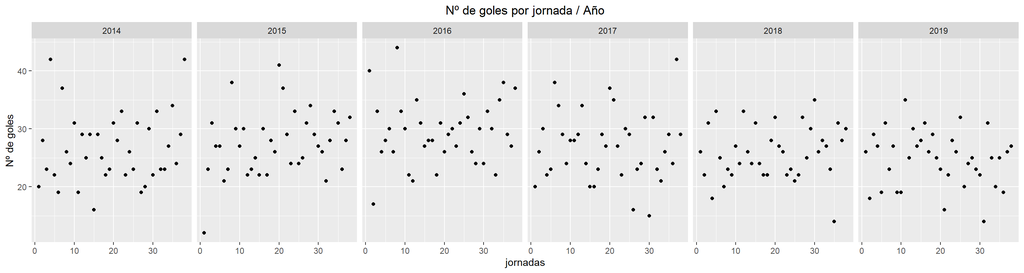

```r
ggplot(goles_year_jorn,  aes(x = jornada, y = total_goles)) + geom_point() + facet_grid(~year) + labs(x = "jornadas", y = "Nº de goles", title = "Nº de goles por jornada / Año") + theme(plot.title = element_text(hjust = 0.5)) + xlim(1,38)
```

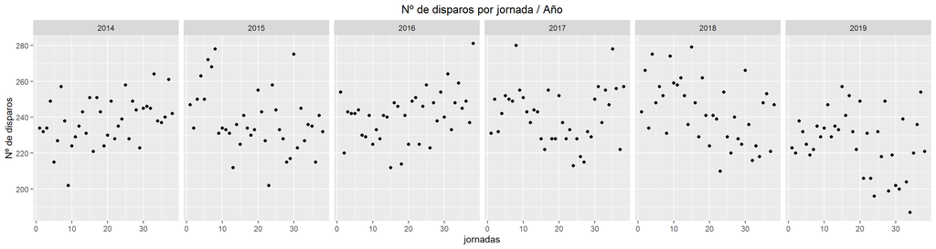

```r
ggplot(tiros_year_jorn,  aes(x = jornada, y = total_tiros)) + geom_point() + facet_grid(~year) + labs(x = "jornadas", y = "Nº de disparos", title = "Nº de disparos por jornada / Año") + theme(plot.title = element_text(hjust = 0.5))
```

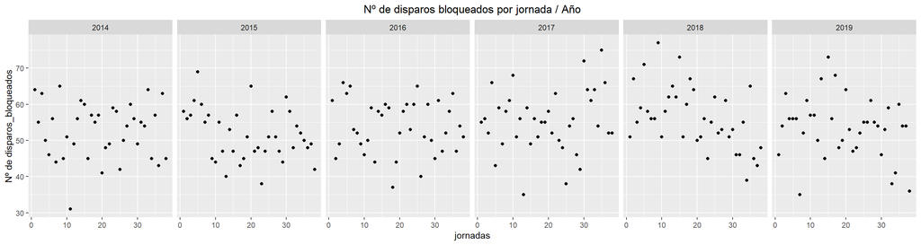

```r
ggplot(tiros_block_year_jorn,  aes(x = jornada, y = total_tiros_bloqueados)) + geom_point() + facet_grid(~year) + labs(x = "jornadas", y = "Nº de disparos_bloqueados", title = "Nº de disparos bloqueados por jornada / Año") + theme(plot.title = element_text(hjust = 0.5))
```

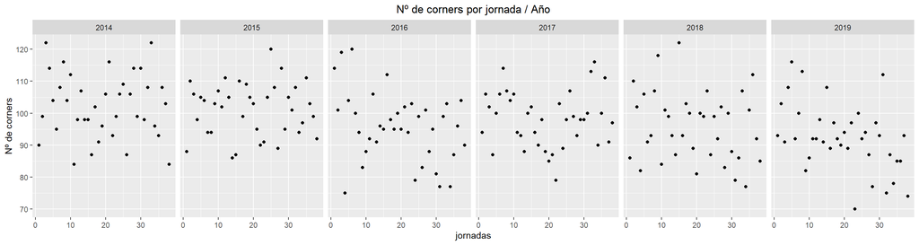

```r
ggplot(corners_year_jorn,  aes(x = jornada, y = total_corners)) + geom_point() + facet_grid(~year) + labs(x = "jornadas", y = "Nº de corners", title = "Nº de corners por jornada / Año") + theme(plot.title = element_text(hjust = 0.5))
```

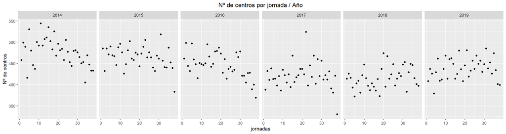

```r
ggplot(centros_year_jorn,  aes(x = jornada, y = total_centros)) + geom_point() + facet_grid(~year) + labs(x = "jornadas", y = "Nº de centros", title = "Nº de centros por jornada / Año") + theme(plot.title = element_text(hjust = 0.5))
```

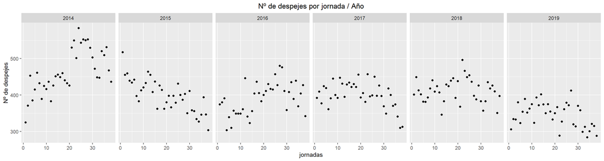

```r
ggplot(t_despj_year_jorn,  aes(x = jornada, y = total_despejes)) + geom_point() + facet_grid(~year) + labs(x = "jornadas", y = "Nº de despejes", title = "Nº de despejes por jornada / Año") + theme(plot.title = element_text(hjust = 0.5))
```

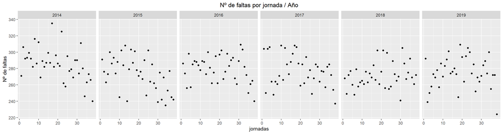

```r
ggplot(faltas_year_jorn,  aes(x = jornada, y = total_faltas)) + geom_point() + facet_grid(~year) + labs(x = "jornadas", y = "Nº de faltas", title = "Nº de faltas por jornada / Año") + theme(plot.title = element_text(hjust = 0.5))
```

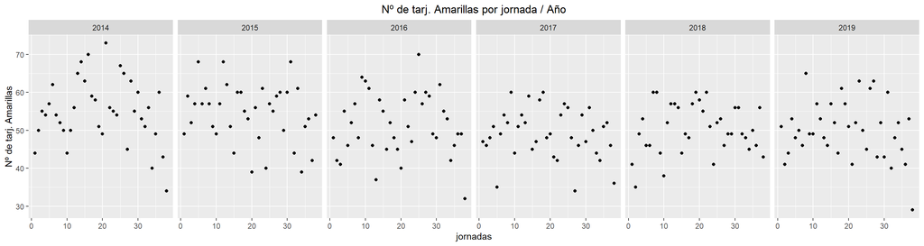

```r
ggplot(amarll_year_jorn,  aes(x = jornada, y = total_amarillas)) + geom_point() + facet_grid(~year) + labs(x = "jornadas", y = "Nº de tarj. Amarillas", title = "Nº de tarj. Amarillas por jornada / Año") + theme(plot.title = element_text(hjust = 0.5))
```

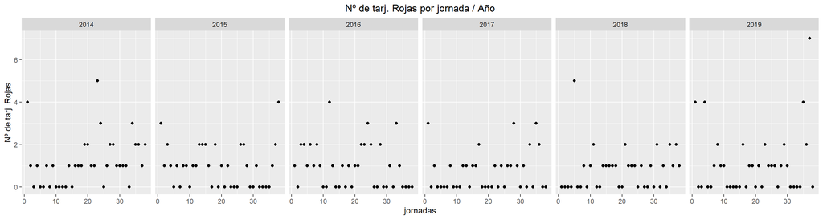

```r
ggplot(rojas_year_jorn,  aes(x = jornada, y = total_rojas)) + geom_point() + facet_grid(~year) + labs(x = "jornadas", y = "Nº de tarj. Rojas", title = "Nº de tarj. Rojas por jornada / Año") + theme(plot.title = element_text(hjust = 0.5))
```

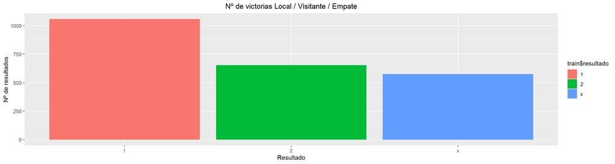

```r
ggplot(train,aes(x=resultado, color = train$resultado, fill = train$resultado)) + geom_bar() + labs(x = "Resultado", y = "Nº de resultados", title = "Nº de victorias Local / Visitante / Empate") + theme(plot.title = element_text(hjust = 0.5))
```

```r
# se ve que jugar en casa es un factor importante para ganar (aprox. la mitad de partidos los gana el de casa)
```

```r
kable(train %>% group_by(resultado) %>% summarise(total_resultados = length(resultado)), "pipe", align = "cc")
```

| resultado | total_resultados |
| --- | --- |
| 1 | 1056 |
| 2 | 651 |
| x | 573 |

```r
#Porcentaje de victorias caseras(TRUE)
prop.table(table(train$Home_Team_Goals_Scored > train$Away_Team_Goals_Scored))
```

```
##
##     FALSE      TRUE
## 0.5368421 0.4631579
```

```r
#Porcentaje de empates
prop.table(table(train$Home_Team_Goals_Scored == train$Away_Team_Goals_Scored))
```

```
##
##     FALSE      TRUE
## 0.7486842 0.2513158
```

```r
#Porcentaje de derrotas caseras
prop.table(table(train$Home_Team_Goals_Scored < train$Away_Team_Goals_Scored))
```

```
##
##     FALSE      TRUE
## 0.7144737 0.2855263
```

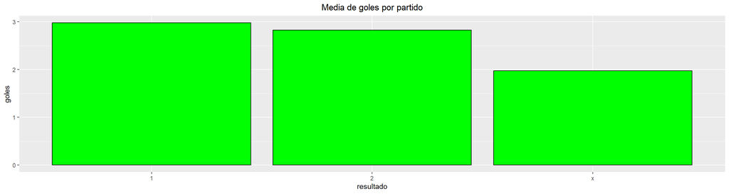

```r
ggplot(train,aes(resultado ,goles)) +
  geom_bar(position = "dodge", stat = "summary", fun = "mean",
           color = 'black', fill = 'green') +
  labs(title="Media de goles por partido", x="resultado", y="goles") +
  theme(plot.title=element_text(hjust = 0.5))
```

```r
# en los partidos con victorias locales hay más goles de media que en los que gana el visitante (y bastante más que en los que hay empate). Por tanto, un partido con más goles es más probable que no acabe en empate.
```

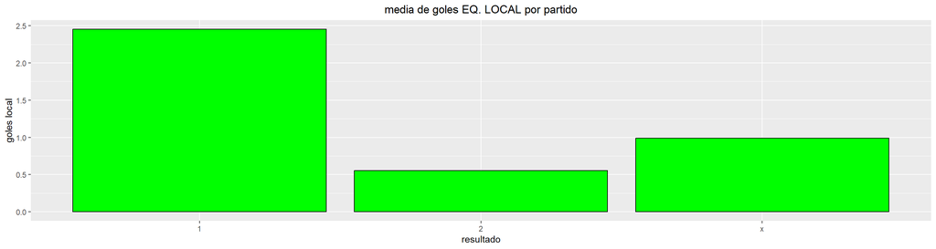

```r
ggplot(train,aes(resultado ,Home_Team_Goals_Scored)) +
  geom_bar(position = "dodge", stat = "summary", fun = "mean",
           color = 'black', fill = 'green') +
  labs(title="media de goles EQ. LOCAL por partido", x="resultado", y="goles local") +
  theme(plot.title=element_text(hjust = 0.5))
```

```r
# Cuando el equipo local gana, mayor es su media de goles. Es decir, a mas goles, mas victorias (obvio pero habia que comprobarlo)
```

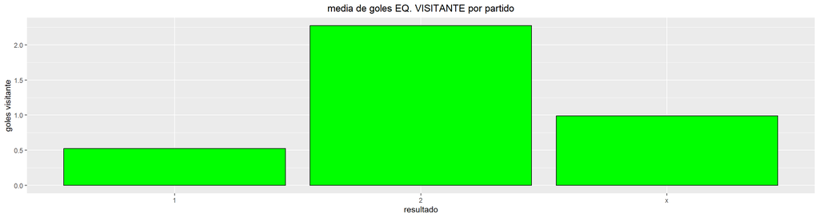

```r
ggplot(train,aes(resultado ,Away_Team_Goals_Scored)) +
  geom_bar(position = "dodge", stat = "summary", fun = "mean",
           color = 'black', fill = 'green') +
  labs(title="media de goles EQ. VISITANTE por partido", x="resultado", y="goles visitante") +
  theme(plot.title=element_text(hjust = 0.5))
```

```r
# Cuando el equipo local pierde, mayor es la media de goles del visitante. Es decir, a mas goles encajados, mas derrotas (obvio pero habia que comprobarlo)
```

```r
#Media de goles por partido
sum(train$Home_Team_Goals_Scored, train$Away_Team_Goals_Scored)/nrow(train)
```

```
## [1] 2.683772
```

```r
#Media de goles por partido con victoria local
sum(Victorias_casa$Home_Team_Goals_Scored,Victorias_casa$Away_Team_Goals_Scored)/nrow(Victorias_casa)
```

```
## [1] 2.980114
```

```r
#Media de goles por partido con victoria visitante
sum(Derrotas_casa$Home_Team_Goals_Scored,Derrotas_casa$Away_Team_Goals_Scored)/nrow(Derrotas_casa)
```

```
## [1] 2.826421
```

```r
#Media de goles por partido con empate
sum(Empates$Home_Team_Goals_Scored,Empates$Away_Team_Goals_Scored)/nrow(Empates)
```

```
## [1] 1.975567
```

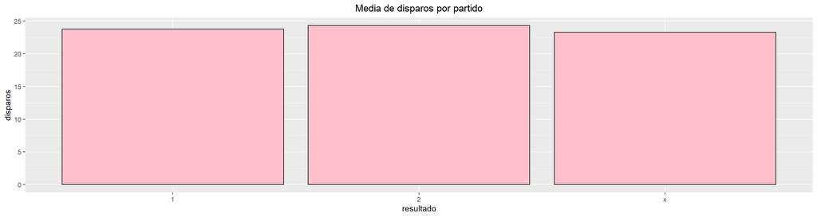

```r
ggplot(train,aes(resultado , total_disparos)) +
  geom_bar(position = "dodge", stat = "summary", fun = "mean",
           color = 'black', fill = 'pink') +
  labs(title="Media de disparos por partido", x="resultado", y="disparos") +
  theme(plot.title=element_text(hjust = 0.5))
```

```r
# en los partidos el numero total de disparos está bastante igualado con independencia de la victoria, derrota o empate.
```

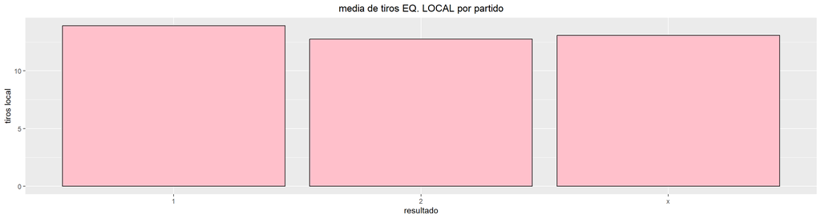

```r
ggplot(train,aes(resultado ,Home_Team_Total_Shots)) +
  geom_bar(position = "dodge", stat = "summary", fun = "mean",
           color = 'black', fill = 'pink') +
  labs(title="media de tiros EQ. LOCAL por partido", x="resultado", y="tiros local") +
  theme(plot.title=element_text(hjust = 0.5))
```

```r
# El número de tiros no influye mucho en el resultado (gane, pierda o empate suelen ser similares)
```

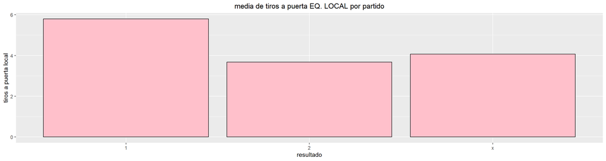

```r
ggplot(train,aes(resultado ,Home_Team_On_Target_Shots)) +
  geom_bar(position = "dodge", stat = "summary", fun = "mean",
           color = 'black', fill = 'pink') +
  labs(title="media de tiros a puerta EQ. LOCAL por partido", x="resultado", y="tiros a puerta local") +
  theme(plot.title=element_text(hjust = 0.5))
```

```r
# Sin embargo el número de tiros a puerta si influye (cuantos más tiros a puerta, más cerca de la victoria)
```

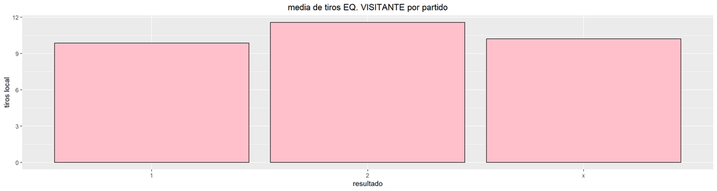

```r
ggplot(train,aes(resultado ,Away_Team_Total_Shots)) +
  geom_bar(position = "dodge", stat = "summary", fun = "mean",
           color = 'black', fill = 'pink') +
  labs(title="media de tiros EQ. VISITANTE por partido", x="resultado", y="tiros local") +
  theme(plot.title=element_text(hjust = 0.5))
```

```r
# Igual que para el equipo local, el número de tiros no influye mucho en el resultado (gane, pierda o empate suelen ser similares)
```

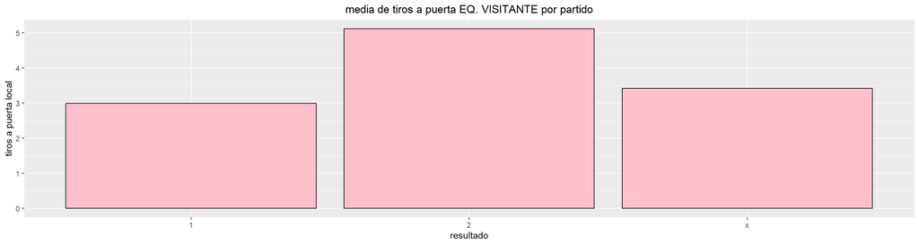

```r
ggplot(train,aes(resultado ,Away_Team_On_Target_Shots)) +
  geom_bar(position = "dodge", stat = "summary", fun = "mean",
           color = 'black', fill = 'pink') +
  labs(title="media de tiros a puerta EQ. VISITANTE por partido", x="resultado", y="tiros a puerta local") +
  theme(plot.title=element_text(hjust = 0.5))
```

```r
# Sin embargo  volvemos a ver que el número de tiros a puerta si influye (cuantos más tiros a puerta, más cerca de la victoria)
```

```r
#Media de disparos por partido
sum(train$Home_Team_Total_Shots, train$Away_Team_Total_Shots)/nrow(train)
```

```
## [1] 23.79035
```

```r
#Media de disparos a puerta partido
sum(train$Home_Team_On_Target_Shots, train$Away_Team_On_Target_Shots)/nrow(train)
```

```
## [1] 8.465351
```

```r
#Media de disparos bloqueados
sum(train$Home_Team_Blocked_Shots, train$Away_Team_Blocked_Shots)/nrow(train)
```

```
## [1] 5.385965
```

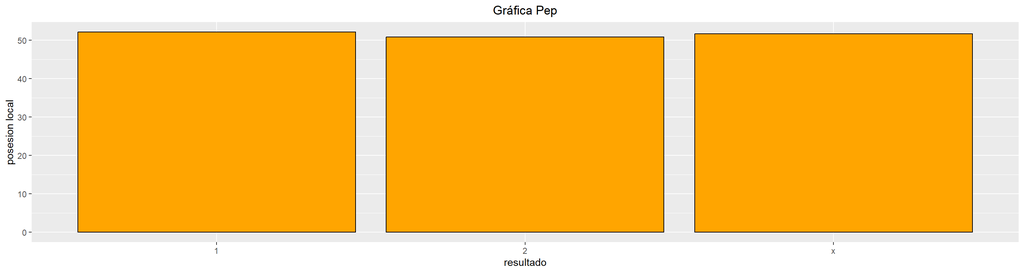

```r
ggplot(train,aes(resultado ,`Home_Team_Possession_%`)) +
  geom_bar(position = "dodge", stat = "summary", fun = "mean",
           color = 'black', fill = 'orange') +
  labs(title="Gráfica Pep", x="resultado", y="posesion local") +
  theme(plot.title=element_text(hjust = 0.5))
```

```r
# No parece influir mucho la posesión
```

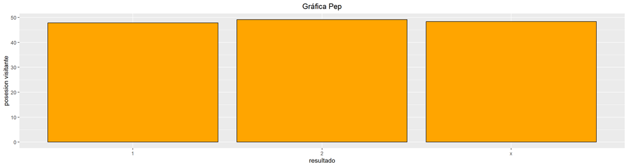

```r
ggplot(train,aes(resultado ,`Away_Team_Possession_%`)) +
  geom_bar(position = "dodge", stat = "summary", fun = "mean",
           color = 'black', fill = 'orange') +
  labs(title="Gráfica Pep", x="resultado", y="posesion visitante") +
  theme(plot.title=element_text(hjust = 0.5))
```

```r
# El equipo local suele tener más posesion (>50%) independientemente del resultado
```

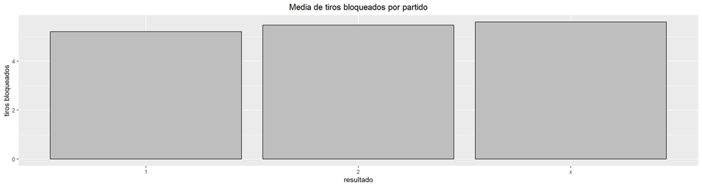

```r
ggplot(train,aes(resultado ,total_disparos_bloqueados)) +
  geom_bar(position = "dodge", stat = "summary", fun = "mean",
           color = 'black', fill = "grey") +
  labs(title="Media de tiros bloqueados por partido", x="resultado", y="tiros bloqueados") +
  theme(plot.title=element_text(hjust = 0.5))
```

```r
# El numero de disparos bloqueados no parece un factor determinante en la victoria
```

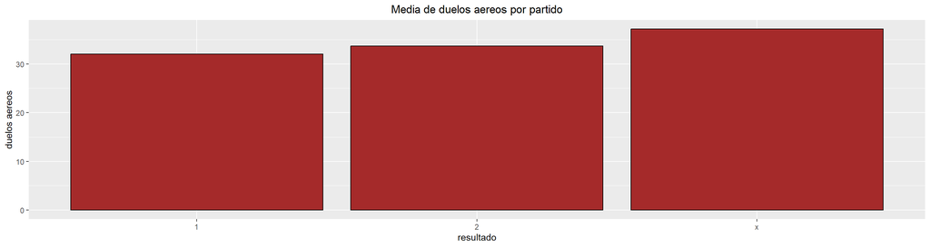

```r
ggplot(train,aes(resultado ,total_d_aereos)) +
  geom_bar(position = "dodge", stat = "summary", fun = "mean",
           color = 'black', fill = "brown") +
  labs(title="Media de duelos aereos por partido", x="resultado", y="duelos aereos") +
  theme(plot.title=element_text(hjust = 0.5))
```

```r
# El numero de duelos aereos no parece un factor determinante en la victoria
```

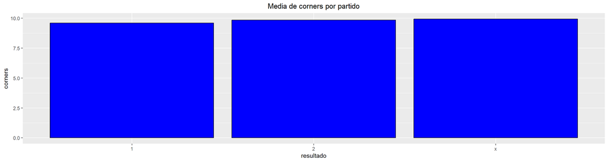

```r
ggplot(train,aes(resultado ,total_corners)) +
  geom_bar(position = "dodge", stat = "summary", fun = "mean",
           color = 'black', fill = 'blue') +
  labs(title="Media de corners por partido", x="resultado", y="corners") +
  theme(plot.title=element_text(hjust = 0.5))
```

```r
# El numero de corners no parece un factor determinante en la victoria se puede observar como con independencia del ganadar el numero de corners está muy repartido
```

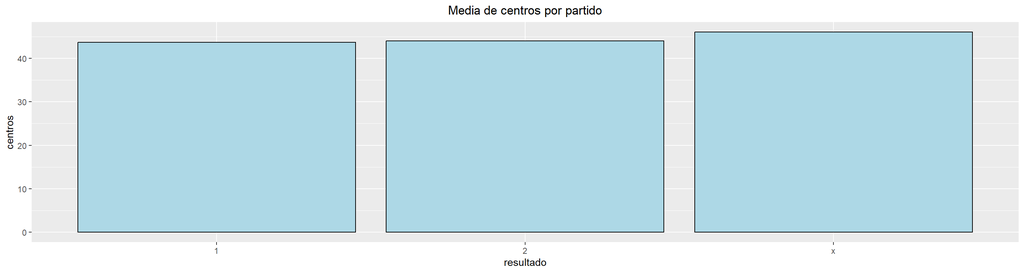

```r
ggplot(train,aes(resultado ,total_centros)) +
  geom_bar(position = "dodge", stat = "summary", fun = "mean",
           color = 'black', fill = 'lightblue') +
  labs(title="Media de centros por partido", x="resultado", y="centros") +
  theme(plot.title=element_text(hjust = 0.5))
```

```r
# El numero de centros no parece un factor determinante en la victoria se puede observar como con independencia del ganadar el numero de centros está muy repartido
```

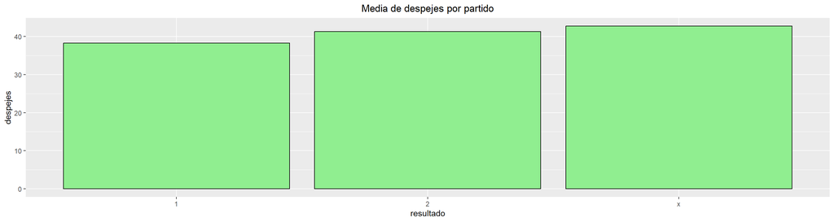

```r
ggplot(train,aes(resultado ,total_despejes)) +
  geom_bar(position = "dodge", stat = "summary", fun = "mean",
           color = 'black', fill = 'lightgreen') +
  labs(title="Media de despejes por partido", x="resultado", y="despejes") +
  theme(plot.title=element_text(hjust = 0.5))
```

```r
# El numero de despejes no parece un factor determinante en la victoria incluso parece que a mayor número de despejes medios el partido parece más probable que acabe en empate
```

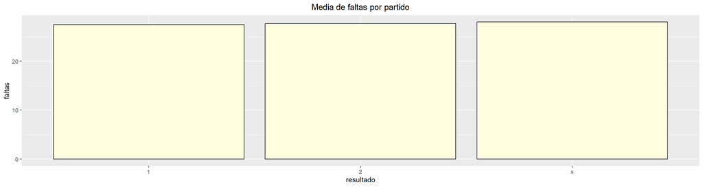

```r
ggplot(train,aes(resultado ,total_faltas)) +
  geom_bar(position = "dodge", stat = "summary", fun = "mean",
           color = 'black', fill = 'lightyellow') +
  labs(title="Media de faltas por partido", x="resultado", y="faltas") +
  theme(plot.title=element_text(hjust = 0.5))
```

```r
# El numero de faltas no parece un factor determinante.
```

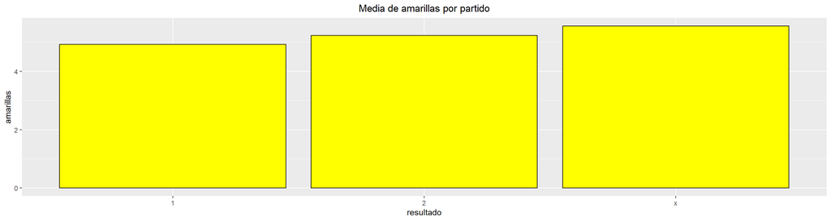

```r
ggplot(train,aes(resultado ,total_amarillas)) +
  geom_bar(position = "dodge", stat = "summary", fun = "mean",
           color = 'black', fill = 'yellow') +
  labs(title="Media de amarillas por partido", x="resultado", y="amarillas") +
  theme(plot.title=element_text(hjust = 0.5))
```

```r
# El numero de tarjetas amarillas no parece un factor determinante.
```

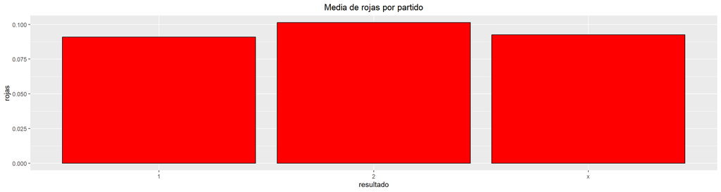

```r
ggplot(train,aes(resultado ,total_rojas)) +
  geom_bar(position = "dodge", stat = "summary", fun = "mean",
           color = 'black', fill = 'red') +
  labs(title="Media de rojas por partido", x="resultado", y="rojas") +
  theme(plot.title=element_text(hjust = 0.5))
```

```r
# El numero de tarjetas rojas no parece un factor determinante.
```

```r
#Puntos promedio por partido por equipo
puntos_promedio_casa <- aggregate((Home_points) ~ Home_Team, data = train, mean)

puntos_promedio_fuera <- aggregate(Away_points ~ Away_Team, data = train, mean)

puntos_promedio <- data.frame(puntos_promedio_casa$Home_Team, (puntos_promedio_casa$`(Home_points)` + puntos_promedio_fuera$Away_points)/2)
names(puntos_promedio) <- c("Equipo", "Puntos_por_partido")
puntos_promedio
```

```
##             Equipo Puntos_por_partido
## 1           ALAVÉS          1.2565789
## 2          ALMERÍA          0.8421053
## 3         ATHLETIC          1.4342105
## 4  ATLETICO MADRID          2.0570175
## 5        BARCELONA          2.3552632
## 6            CELTA          1.2412281
## 7          CÓRDOBA          0.5263158
## 8        DEPORTIVO          0.9342105
## 9            EIBAR          1.1929825
## 10           ELCHE          1.0789474
## 11        ESPANYOL          1.2061404
## 12          GETAFE          1.2684211
## 13           GIJÓN          0.9210526
## 14          GIRONA          1.1578947
```

[output cut: 16 more lines]

```r
#Esta seria la clasificacion con la media de puntos por partido por equipo
clasificacion_media <- arrange(puntos_promedio,desc(Puntos_por_partido))
clasificacion_media
```

```
##             Equipo Puntos_por_partido
## 1        BARCELONA          2.3552632
## 2      REAL MADRID          2.2192982
## 3  ATLETICO MADRID          2.0570175
## 4       SEVILLA FC          1.6973684
## 5       VILLARREAL          1.5614035
## 6         VALENCIA          1.5526316
## 7         ATHLETIC          1.4342105
## 8    REAL SOCIEDAD          1.3728070
## 9           GETAFE          1.2684211
## 10          ALAVÉS          1.2565789
## 11           CELTA          1.2412281
## 12      REAL BETIS          1.2368421
## 13        ESPANYOL          1.2061404
## 14           EIBAR          1.1929825
```

[output cut: 16 more lines]

```r
aggregate(Home_Team_Goals_Scored ~ Home_Team, data = train, FUN = mean) -> goles_home_team
goles_home_team
```

```
##          Home_Team Home_Team_Goals_Scored
## 1           ALAVÉS              1.0394737
## 2          ALMERÍA              1.0526316
## 3         ATHLETIC              1.4473684
## 4  ATLETICO MADRID              1.7982456
## 5        BARCELONA              3.0789474
## 6            CELTA              1.5438596
## 7          CÓRDOBA              0.6315789
## 8        DEPORTIVO              1.2631579
## 9            EIBAR              1.3771930
## 10           ELCHE              1.0000000
## 11        ESPANYOL              1.1929825
## 12          GETAFE              1.2421053
## 13           GIJÓN              1.4210526
## 14          GIRONA              1.1315789
```

[output cut: 16 more lines]

```r
aggregate(Away_Team_Goals_Scored ~ Away_Team, data = train, FUN = mean) -> goles_Away_team
goles_Away_team
```

```
##          Away_Team Away_Team_Goals_Scored
## 1           ALAVÉS              0.9868421
## 2          ALMERÍA              0.7894737
## 3         ATHLETIC              0.9736842
## 4  ATLETICO MADRID              1.3947368
## 5        BARCELONA              2.2982456
## 6            CELTA              1.0877193
## 7          CÓRDOBA              0.5263158
## 8        DEPORTIVO              0.8552632
## 9            EIBAR              0.9736842
## 10           ELCHE              0.8421053
## 11        ESPANYOL              0.9736842
## 12          GETAFE              0.8947368
## 13           GIJÓN              0.7368421
## 14          GIRONA              1.1578947
```

[output cut: 16 more lines]

```r
goles_por_equipo <- data.frame(goles_home_team$Home_Team,(goles_Away_team$Away_Team_Goals_Scored + goles_home_team$Home_Team_Goals_Scored)/2)
names(goles_por_equipo) <- c("equipo", "goles")
goles_por_equipo
```

```
##             equipo     goles
## 1           ALAVÉS 1.0131579
## 2          ALMERÍA 0.9210526
## 3         ATHLETIC 1.2105263
## 4  ATLETICO MADRID 1.5964912
## 5        BARCELONA 2.6885965
## 6            CELTA 1.3157895
## 7          CÓRDOBA 0.5789474
## 8        DEPORTIVO 1.0592105
## 9            EIBAR 1.1754386
## 10           ELCHE 0.9210526
## 11        ESPANYOL 1.0833333
## 12          GETAFE 1.0684211
## 13           GIJÓN 1.0789474
## 14          GIRONA 1.1447368
```

[output cut: 16 more lines]

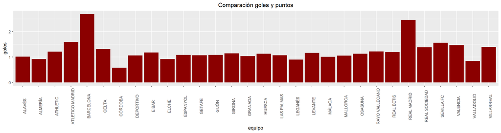

```r
#No he sido capaz de poner encima una grafica de densidad con los puntos de cada equipo
ggplot(goles_por_equipo, aes(x = equipo, y = goles)) +
  geom_bar(position = "dodge", stat = "summary", fill = "darkred") +
  labs(title = "Comparación goles y puntos") +
  theme(plot.title = element_text(hjust = 0.5), axis.text.x = element_text(angle = 90))
```

```r
#Porcentaje medio de posesión por equipo en casa
tapply(train$`Home_Team_Possession_%`,train$`Home_Team`,mean)
```

```
##          ALAVÉS         ALMERÍA        ATHLETIC ATLETICO MADRID       BARCELONA
##        43.86842        45.42105        51.60526        50.35965        66.31579
##        CÁDIZ CF           CELTA         CÓRDOBA       DEPORTIVO           EIBAR
##              NA        56.37719        51.47368        49.11842        50.61404
##           ELCHE        ESPANYOL          GETAFE           GIJÓN          GIRONA
##        50.05263        48.02632        44.64211        45.89474        49.52632
##         GRANADA          HUESCA      LAS PALMAS         LEGANÉS         LEVANTE
##        46.69737        47.31579        58.73684        45.60526        46.25263
##          MÁLAGA        MALLORCA         OSASUNA  RAYO VALLECANO      REAL BETIS
##        48.85526        42.89474        45.47368        54.57895        55.57895
##     REAL MADRID   REAL SOCIEDAD      SEVILLA FC        VALENCIA      VALLADOLID
##        60.01754        55.49123        56.39474        49.71930        47.60526
##      VILLARREAL
##        51.55263
```

```r
#Porcentaje medio de posesión por equipo fuera de casa
tapply(train$`Away_Team_Possession_%`,train$`Away_Team`,mean)
```

```
##          ALAVÉS         ALMERÍA        ATHLETIC ATLETICO MADRID       BARCELONA
##        39.93421        42.31579        48.71930        46.68421        66.14035
##        CÁDIZ CF           CELTA         CÓRDOBA       DEPORTIVO           EIBAR
##              NA        52.42105        41.21053        45.23684        45.45614
##           ELCHE        ESPANYOL          GETAFE           GIJÓN          GIRONA
##        44.89474        44.92105        41.80000        41.42105        45.44737
##         GRANADA          HUESCA      LAS PALMAS         LEGANÉS         LEVANTE
##        42.86842        41.21053        53.70175        41.26316        43.56842
##          MÁLAGA        MALLORCA         OSASUNA  RAYO VALLECANO      REAL BETIS
##        46.07895        46.15789        40.94737        53.59649        53.07368
##     REAL MADRID   REAL SOCIEDAD      SEVILLA FC        VALENCIA      VALLADOLID
##        57.20175        52.43860        51.73684        48.09649        43.36842
##      VILLARREAL
##        46.90351
```

```r
summary(Empates$`Home_Team_Possession_%`)
```

```
##    Min. 1st Qu.  Median    Mean 3rd Qu.    Max.
##   21.00   45.00   52.00   51.69   59.00   81.00
```

```r
summary(Victorias_casa$`Home_Team_Possession_%`)
```

```
##    Min. 1st Qu.  Median    Mean 3rd Qu.    Max.
##   22.00   44.00   52.00   52.18   60.00   83.00
```

```r
summary(Derrotas_casa$`Home_Team_Possession_%`)
```

```
##    Min. 1st Qu.  Median    Mean 3rd Qu.    Max.
##   19.00   43.00   52.00   50.86   59.00   80.00
```

```r
#Con estos datos tan similares sacamos en conclusión que la posesión no ha influido mucho en las victorias(pobre Pep)
```

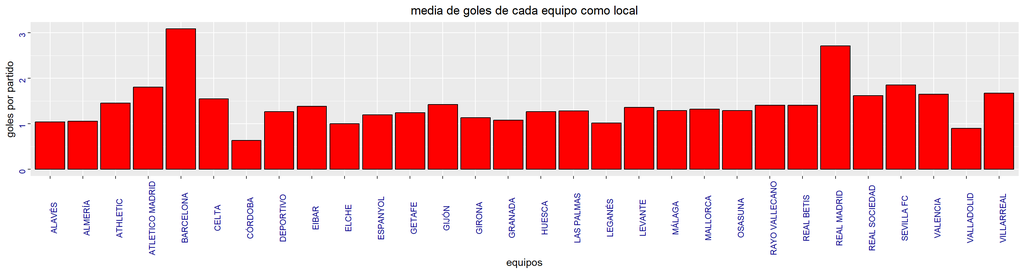

```r
ggplot(train,aes(Home_Team ,Home_Team_Goals_Scored)) +
  geom_bar(position = "dodge", stat = "summary", fun = "mean",
           color = 'black', fill = 'red') +
  labs(title="media de goles de cada equipo como local", x="equipos", y="goles por partido") +
  theme(plot.title=element_text(hjust = 0.5), axis.text = element_text(angle = 90, color = "darkblue"))
```